# Red Wine Data Exploration by Mario Hinojosa

### Description Two

Alcohol median is notably higher for good quality wines, that is, grade 7 and 8. The latter having a median above 12%. However, there are some seemingly outlier wines that have high alcohol content but are graded as average (5 - 6). Both grade 7 and 8’s alcohol distribution is left skewed and peak at 12% or above.

### Plot Three

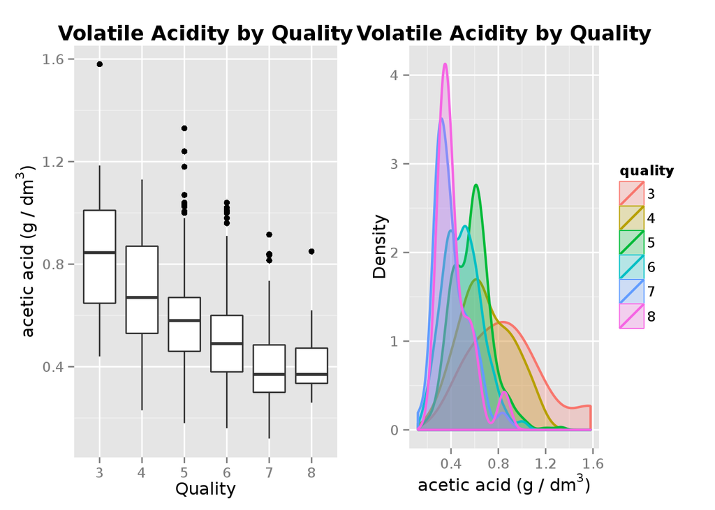

# Reflection

The red wine dataset consists of 1599 observations of red variants of the Portuguese “Vinho Verde” wine.

The exploratory process began by understanding individual variables via summary statistics and histograms. This gave me a sense of the distribution of each individual variable but what really started to get me going and asking questions was after I plotted the correlation matrix as I was able to quickly see which variables seemed to have closer relationship with quality of wine such as alcohol, sulphates, volatility acid and specially citric acid. The following steps consisted of plotting in more detail the features I found interesting and trying to see if there was a pattern.

During my exploration I noticed that the number of observations varied widely from one quality level to another (5 and 6 had significantly more observations). I believe this could be a limitation on the data as ideally, one would be looking for enought data point at each quality level so as to make the statistical methods more robust. Moreover, I find quite strange that the dataset didn’t have any observations with quality levels below 3 and above 8. I have a feeling that this could also affect the robustness of statistical methods applied to this dataset.

My main struggle was not being able to fit a linear regression with quality as the dependent variable. This was due to the fact that at this point I don’t know how to apply a similar method when the dependent variable is categorial. Thinking how to expand my analysis, I believe that understanding how probit or logit regressions work would allow me to fit a model and obtain some numbers on the relationships I identified via plots.